# DEADLY GRAPHS, FOR THE RUSSIANS

These graphs show the Russian lossses **in the first 42 days of each year of this war** (Feb 24 to April 6th). This starting date is used because the large scale Russian invasion started on Feb 24th, 2022.

[data source](https://onedrive.live.com/edit?id=E33161B435D127BA!157482&resid=E33161B435D127BA!157482&ithint=file%2Cxlsx&authkey=!AHy27V-_Woq340I&wdo=2&cid=e33161b435d127ba) from which these graphs are derived.

The first figure and graph show how Russian Personnel losses are growing disastrously for them each year.

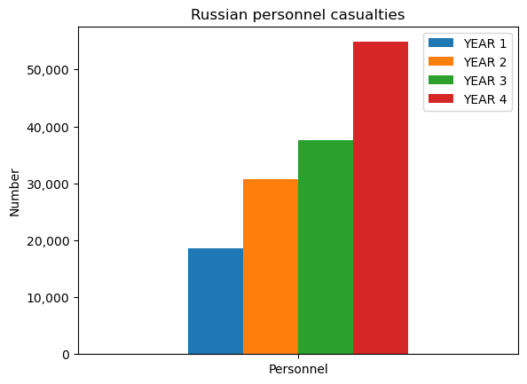

| ITEM | YEAR 1 | YEAR 2 | YEAR 3 | YEAR 4 |
| --- | --- | --- | --- | --- |
| Personnel | 18,600 | 30,780 | 37,660 | 54,840 |

The graph below shows their increasingly heavy losses with Drones, Vehicle & Fuel Tanks and Artillery.

On the other hand their losses with Tanks and Armoured Personnel Vehicles (APV) have been steady or declining. They have stopped sending them into battle because Ukraine has been successful in destroying them.

**acronyms**  
MLRS Multiple Launch Rocket Systems  
APV Armoured Personnel Vehicles  
UAV Unmanned Aerial Vehicles (drones)

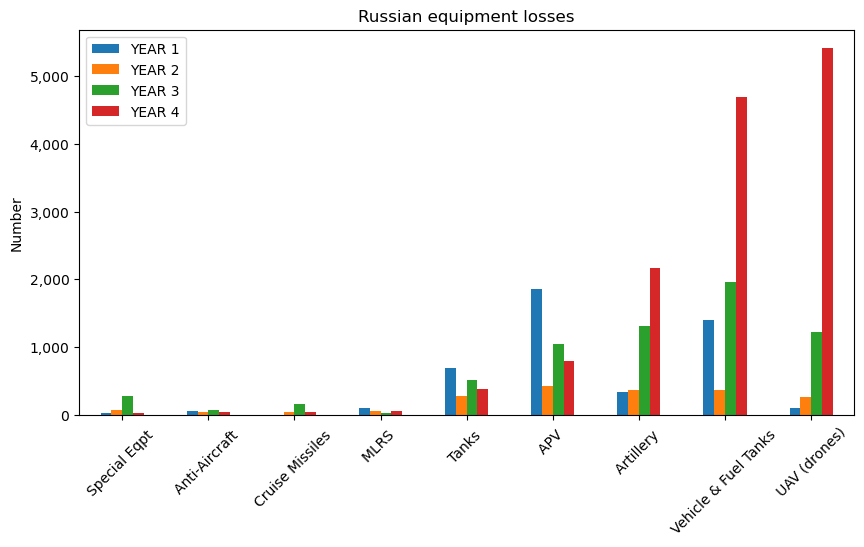

| ITEM | YEAR 1 | YEAR 2 | YEAR 3 | YEAR 4 |
| --- | --- | --- | --- | --- |
| Special Eqpt | 25 | 74 | 274 | 32 |
| Anti-Aircraft | 55 | 37 | 65 | 42 |
| Cruise Missiles | 0 | 38 | 156 | 45 |
| MLRS | 107 | 61 | 30 | 55 |
| Tanks | 684 | 281 | 507 | 386 |
| APV | 1,861 | 420 | 1,049 | 800 |
| Artillery | 332 | 362 | 1,305 | 2,166 |
| Vehicle & Fuel Tanks | 1,400 | 359 | 1,962 | 4,690 |
| UAV (drones) | 96 | 258 | 1,219 | 5,418 |

The final graph shows the Russians taking heavy losses with Warships, Helicopters and Aircraft in the first year. Once again, they are mainly being held in reserve rather than risk further losses.

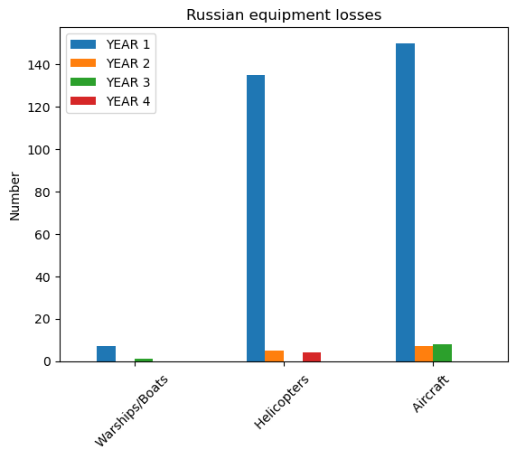

| DATE | YEAR 1 | YEAR 2 | YEAR 3 | YEAR 4 |
| --- | --- | --- | --- | --- |
| Warships/Boats | 7 | 0 | 1 | 0 |
| Helicopters | 135 | 5 | 0 | 4 |
| Aircraft | 150 | 7 | 8 | 0 |

**Conclusion**: Russia is losing this war.